# Excess mortality: data preparation

# HMD

[The Human Mortality Database](https://www.mortality.org/) data.

```r
password <- readr::read_file("secrets/HMD.txt")

# pop
hmd_ch_pop_raw <- readHMDweb(CNTRY = "CHE", item ="Population" ,
                             username = "r.panczak@gmail.com",
                             password = password,
                             fixup = FALSE)  %>%
  as_tibble()

# deaths
hmd_ch_deaths_raw <- readHMDweb(CNTRY = "CHE", item = "Deaths_1x1",
                                username = "r.panczak@gmail.com",
                                password = password,
                                fixup = FALSE)  %>%
  as_tibble()

write_rds(hmd_ch_deaths_raw, "data-raw/mortality_org/hmd_ch_deaths_raw.Rds")
write_dta(hmd_ch_deaths_raw, "data-raw/mortality_org/hmd_ch_deaths_raw.dta")
```

Available only yearly but for one year age bands & separate by sex. Time from 1876 to 2018.

Data is aggregated by year to match other sources.

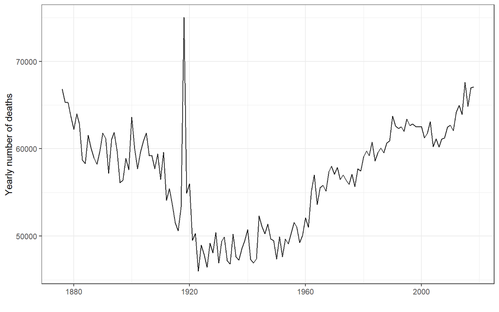

Similarly, population data is aggregated by year.

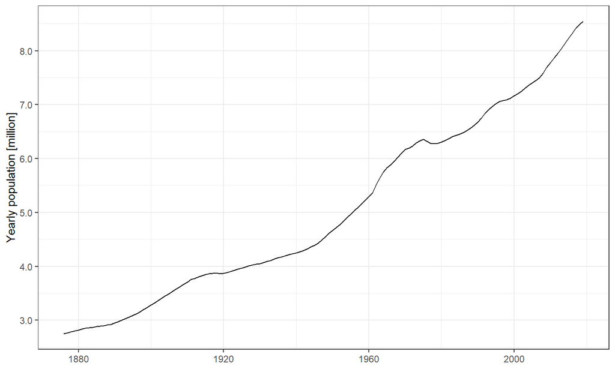

Advantage of data is availability of age bands (1 year!)

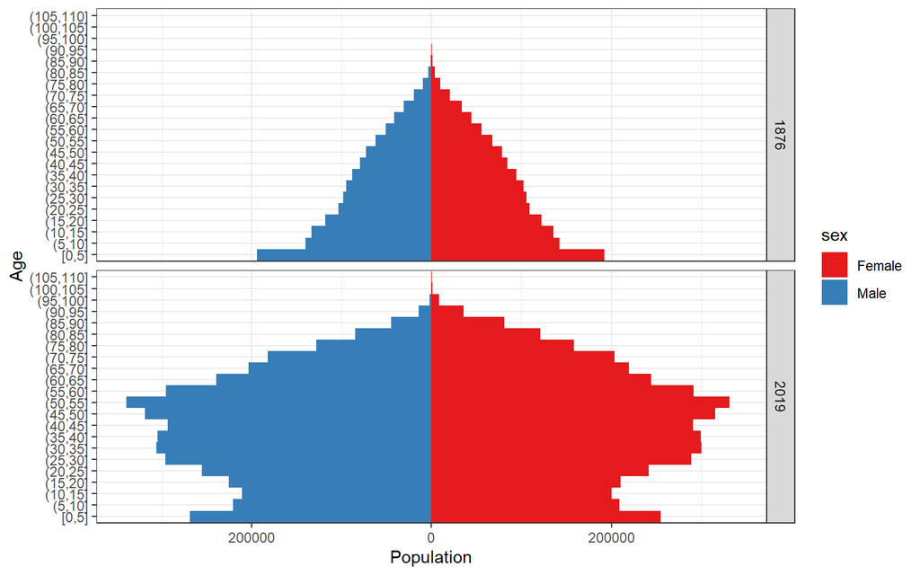

# BfS 1

## Deaths

Data from [Todesfälle nach Monat und Sterblichkeit seit 1803](https://www.bfs.admin.ch/bfs/de/home/statistiken/kataloge-datenbanken/daten.assetdetail.14387168.html)

```r
bfs_web_raw <- read_xlsx("data-raw/BfS/px-x-0102020206_111_20210223-102443.xlsx",
                         skip = 2, na = "...") %>%
  remove_empty() %>%
  clean_names() %>%
  rename(year = x1) %>%
  filter(!is.na(todesfalle_total)) %>%
  select(year:todesfalle_im_dezember) %>%
  mutate(year = as.numeric(year))

bfs_web_deaths_yearly <- bfs_web_raw %>%
  select(year, todesfalle_total) %>%
  rename(deaths_year = todesfalle_total)

p1 <- bfs_web_deaths_yearly %>%
  uncount(12) %>%
  group_by(year) %>%
  mutate(month_num = row_number()) %>%
  ungroup()

p2 <- bfs_web_raw %>%
  select(-todesfalle_total) %>%
  filter(!is.na(todesfalle_im_januar)) %>%
  pivot_longer(!year, names_to = "month", values_to = "deaths_month") %>%
  mutate(month = str_replace(month, fixed("todesfalle_im_"), "")) %>%
  group_by(year) %>%
  mutate(month_num = row_number()) %>%
  ungroup() %>%
  select(-month)

bfs_web_deaths_monthly <- p1 %>%
  left_join(p2) %>%
  mutate(date = anytime::anydate(paste0(year, "-", month_num))) %>%
  relocate(year, month_num, date) %>%
  mutate(type = if_else(is.na(deaths_month), "yearly", "monthly"))

write_rds(bfs_web_deaths_monthly, "data/BfS/bfs_web_deaths_monthly.Rds")
write_dta(bfs_web_deaths_monthly, "data/BfS/bfs_web_deaths_monthly.dta")
```

Yearly deaths for period 1803 to 2019; monthly deaths for period 1901 to 2019, with special addition of period 1877 to 1885.

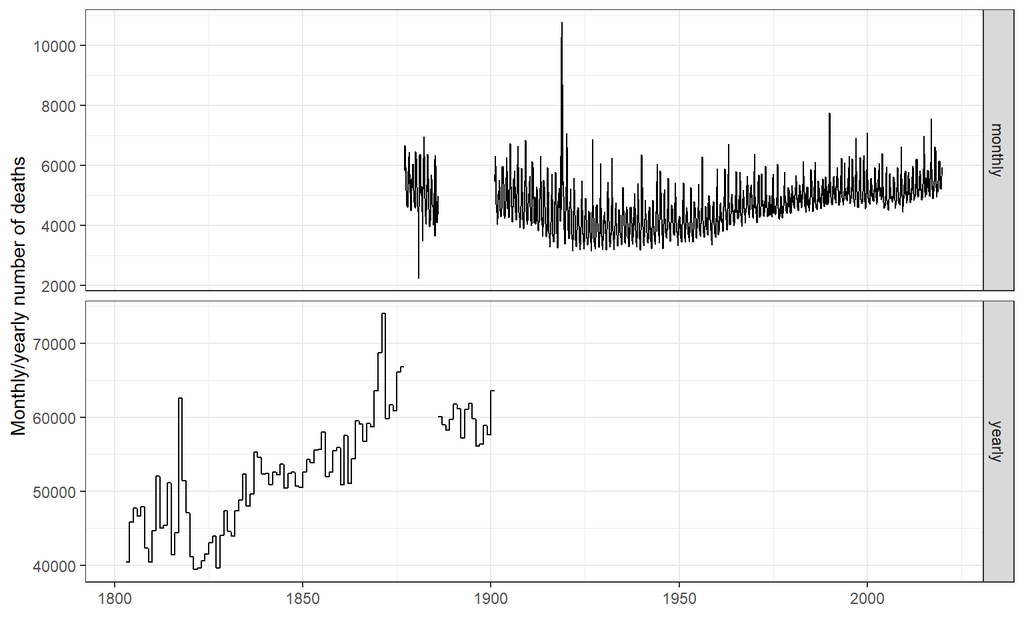

Note different `y` scales!

```r
inconsistent <- bfs_web_deaths_monthly %>%
  filter(!is.na(deaths_month)) %>%
  group_by(year) %>%
  mutate(deaths_summed = sum(deaths_month)) %>%
  ungroup() %>%
  filter(deaths_year != deaths_summed)
```

There are three years where summed monthly data differ from ‘official’ yearly sums.

| year | deaths_year | deaths_summed | difference |
| --- | --- | --- | --- |
| 1880 | 62223 | 60223 | 2000 |
| 1881 | 63979 | 63079 | 900 |
| 1885 | 61548 | 59548 | 2000 |

## Pops

[Demographic balance of the permanent resident population, 1861-2019](https://www.bfs.admin.ch/bfs/en/home/statistics/catalogues-databases/tables.assetdetail.13707412.html)

```r
bfs_web_pop_yearly <- read_xlsx("data-raw/BfS/su-e-01.02.04.05.xlsx",
                                na = "...", skip = 1) %>%
  remove_empty(c("rows", "cols")) %>%
  clean_names() %>%
  rename(year = x1, pop_jan = population_on_2, pop_dec = population_on_11) %>%
  filter(!is.na(year)) %>%
  filter(!is.na(pop_jan)) %>%
  mutate(year = if_else(year == "2010 7", "2010", year),
         year = as.numeric(year),
         pop_jan = as.numeric(pop_jan),
         pop_dec = as.numeric(pop_dec)) %>%
  select(year, starts_with("pop_"))
```

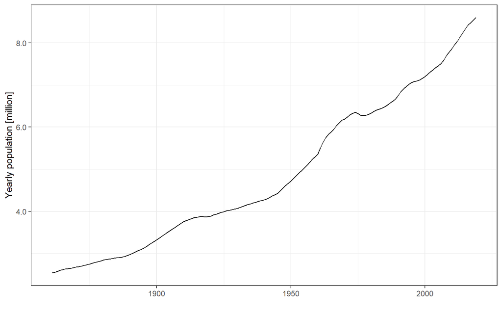

# Comparison - pops

```r
compare <- left_join(
  bfs_web_pop_yearly,
  hmd_ch_pop_year) %>%
  mutate(diff1 = pop_jan - pop_year) %>%
  mutate(diff2 = pop_dec - pop_year)
```

Summary of differences between BfS figures (both Jan and Dec) and HMD

```r
summary(compare$diff1)
```

```
    Min.  1st Qu.   Median     Mean  3rd Qu.     Max.     NA's
-3759.90   -93.15   365.08   912.73   723.17  9415.92       15
```

```r
summary(compare$diff2)
```

```
   Min. 1st Qu.  Median    Mean 3rd Qu.    Max.    NA's
 -36450   19649   38088   41541   61525  147995      15
```

Timeline of differences between BfS figures and HMD

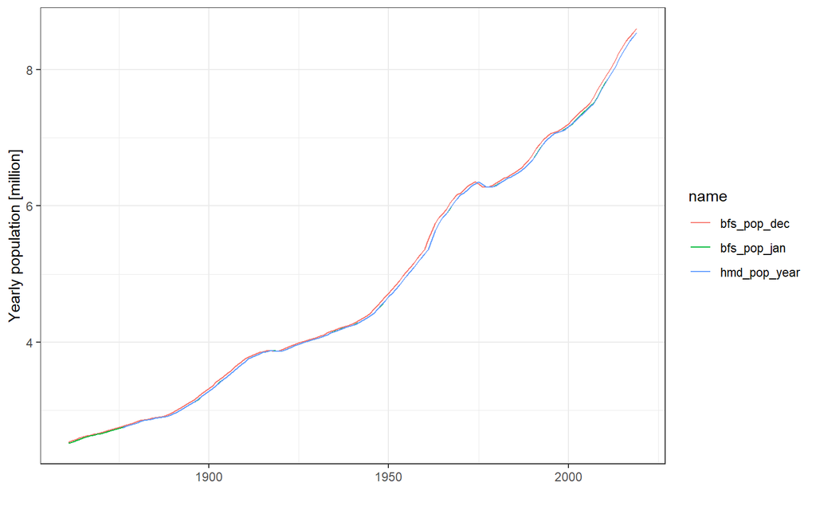

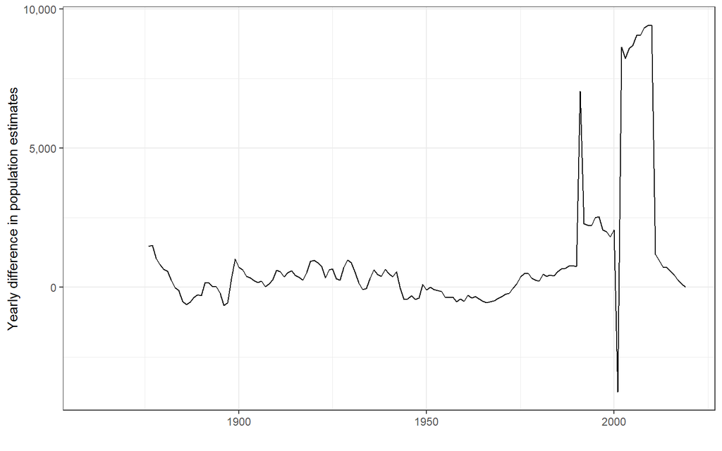

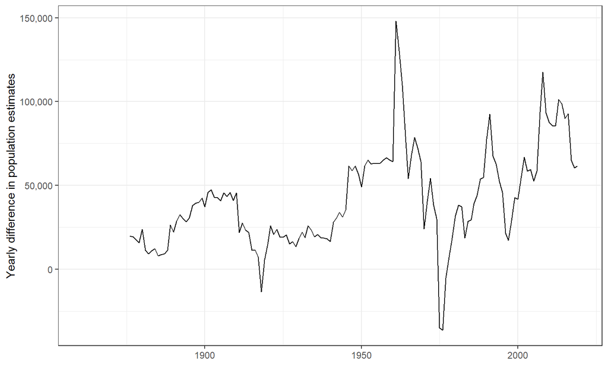

# Comparison - deaths

```r
compare <- left_join(
  bfs_web_deaths_yearly %>%
    rename(deaths_year_bfs = deaths_year),
  hmd_ch_deaths %>%
    rename(deaths_year_hmd = deaths_year)
) %>%
  mutate(diff = deaths_year_bfs - deaths_year_hmd)
```

Summary of differences between BfS figures and HMD

```r
summary(compare$diff)
```

```
    Min.  1st Qu.   Median     Mean  3rd Qu.     Max.     NA's
-77.0000  -0.0050   0.0000  -0.2378   0.0000 117.0000       74
```

Timeline of differences between BfS figures and HMD

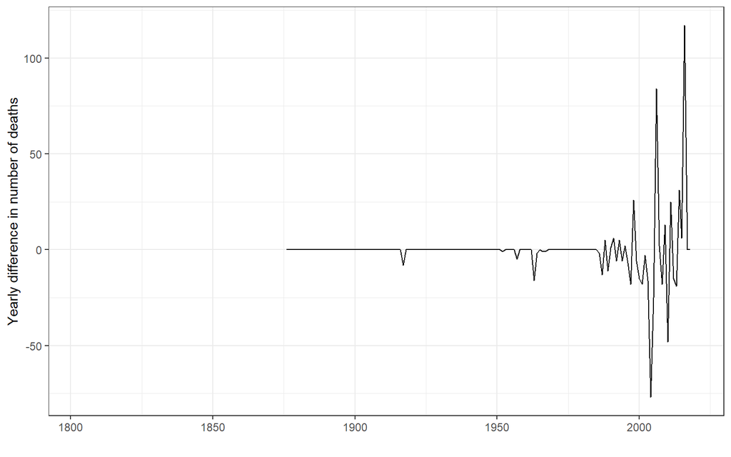

To cite R in publication use:

R Core Team (2021). *R: A Language and Environment for Statistical Computing*. R Foundation for Statistical Computing, Vienna, Austria. https://www.R-project.org/.